# The World’s Hardest Boulder Problems Sent by Men (V15 and up)

**Table of Contents:**  
The World’s Hardest Boulder Problems Sent by Men  
The World’s Current Hardest Boulder Problem  
Who Is the Strongest Male Boulderer Ever?  
Trends Over Time  
How Many Men Can Climb V15 or Higher?  
Which Countries Have the Hardest Boulder Problems?  
What About Age?  
Height?

**Last updated:** January 2022. If you notice anything that is an error, or you would like to help improve the list, please let me know.

[Note: this site and list are still under construction. Things I still need to do:  
- Fix table of contents  
- Add ability for users to comment]

The following is an attempt to update [Alex Beale](https://www.99boulders.com/author/alex)’s fantastic list of [The World’s Hardest Boulder Problems](https://www.99boulders.com/hardest-boulder-problems), which attempted to collect the hardest boulder problems with a lower cutoff grade of V15 (8C).

As of January 2022, Mr. Beale has not updated the site past March of 2019. This is really unfortunate as hard bouldering has really jumped starting in 2019 (which show). The following is my attempt to create the most up-to-date list of hard boulder sends.

As it stands, there are currently 826 entries; of which 826 have dates.

As of this writing, there now appear to be 205 climbs rated **V15 (8C)**, 38 climbs rated **V16 (8C+)**, and 2 climbs rated **V17 (9A)**.

Compared to Alex Beale’s list, that is 26 more V16s than there were in March 2019!

The most climbed **V15** boulder is **Story Of Two Worlds** with 27 ascents; followed by **Big Island** and **Dreamtime (post break)** with 24 and 21 ascents, respectively.

The most climbed **V16** boulder is **Creature from the Black Lagoon** with 11 ascents; followed by **Sleepwalker** and **Off the Wagon Sit** with 8 and 7 ascents, respectively.

[Here is a link](https://bit.ly/3FYSddM) to the Google Spreadsheet

# The World’s Hardest Boulder Problems Sent by Men

| Route Name | Climber | Consensus VGrade | FA | Country | Area | Date | Suggested VGrade by Climber | Repeated? |
| --- | --- | --- | --- | --- | --- | --- | --- | --- |
| 4-Low | Daniel Woods | 15 | FA | Switzerland | Valle Bavona | 2020-03-15 | 15 | Unrepeated |
| Airian | Alberto Rocasolano | 15 |  | Spain | Baltzola | 2016-06-06 | 15 | Repeated |
| Airian | Iban Larrion | 15 | FA | Spain | Baltzola | 2012-03-15 | 15 | Repeated |
| Alchimiste (right) | Alban Levier | 15 |  | France | Fontainebleau | 2016-01-28 | 15 | Repeated |
| Alchimiste (right) | Nalle Hukkataival | 15 | FA | France | Fontainebleau | 2015-03-16 | 16 | Repeated |
| Amazonia | Francis Helias | 15 | FA | France | Fontainebleau | 2002-06-30 | 15 | Unrepeated |
| Ambition | James Squire | 15 | FA | United Kingdom | Biblins Cave | 2020-06-16 | 15 | Unrepeated |
| Anarchiste, L' | Philip Moser | 15 | FA | France | St Anne | 2003-03-23 | 15 | Unrepeated |
| Angama | Dai Koyamada | 15 | FA | France | Fontainebleau | 2006-10-24 | 15 | Repeated |
| Angama | Paul Robinson | 15 |  | France | Fontainebleau | 2011-03-23 | 15 | Repeated |

[output cut: 816 more lines]

# The World’s Hardest Boulder Problem

Based solely on grade, the title of world’s hardest boulder problem is currently shared by two problems: [Burden of Dreams](https://climbing-history.org/climb/826/burden-of-dreams) and [Return of the Sleepwalker](https://climbing-history.org/climb/1116/return-of-the-sleepwalker). Both are currently graded V17 (9A).

Both problems have only one ascent. Nalle Hukkataival sent Burden of Dreams in October 2016, making it the first problem ever to receive a proposed grade of V17 (9A). Daniel Woods sent Return of the Sleepwalker in March 2021.

# Who Is the Strongest Male Boulderer Ever?

The following are two bar plots based on the data in the above list showing who has sent the most hard boulder problems and who has put up the most hard boulder first ascents (FAs).

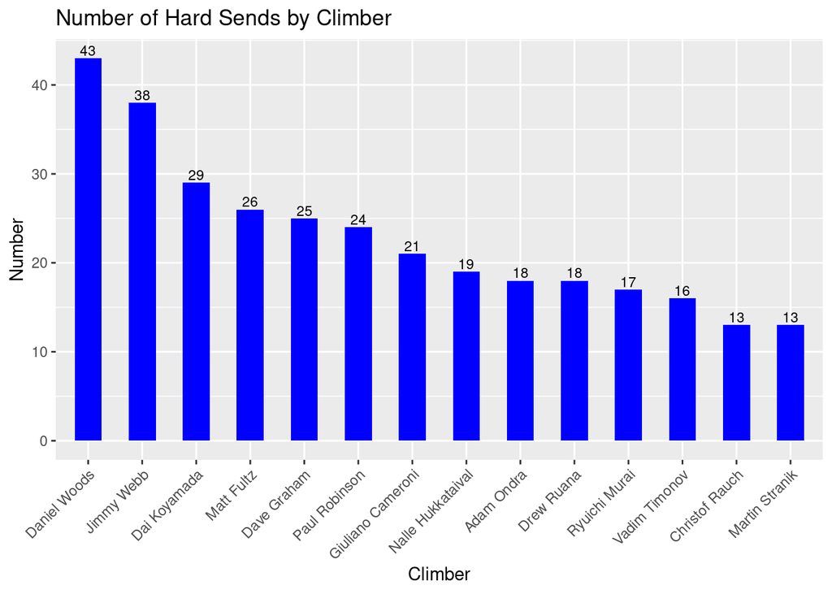

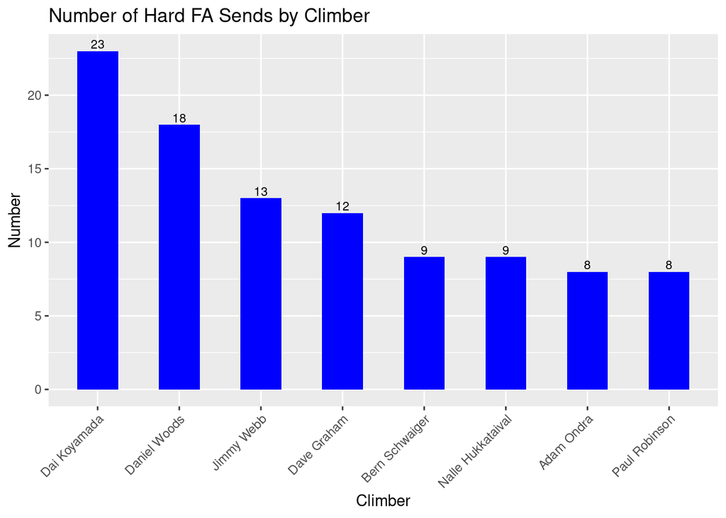

The strongest climber by most hard boulder sends is Daniel Woods with 43 ascents; 5 more than the Jimmy Webb with the second most ascents. However, Dai Koyamada has the most FAs with 23; 5 more than Daniel Woods, and an impressive amount of hard sends to his name. Finally, both Daniel Woods and Nalle Hukkataival are the only climbers to have sent a V17.

# Trends Over Time

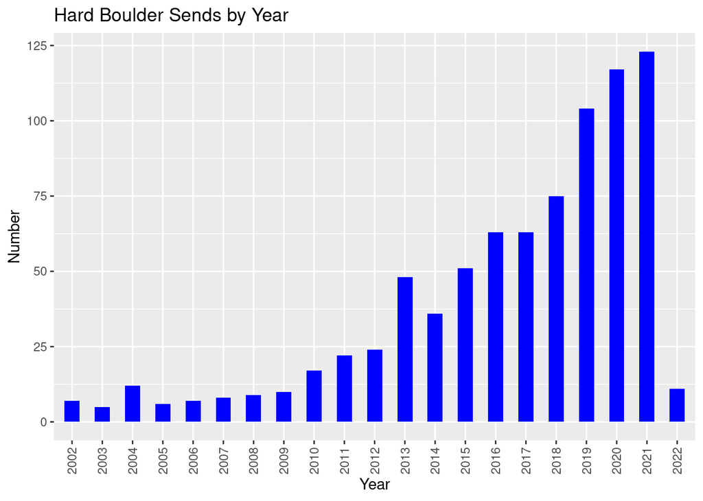

It took two years from the first suggested V15 (Dreamtime (pre-break)) to a consensus V15 (Black Eagle SD / Monkey Wedding). For V16, the first suggested problem appears to have been Tonino ’78, first sent by Mauro Calibani in 2004. But it wouldn’t be until 2016 (12 years later) when Daniel Woods put up [Creature from the Black Lagoon](https://climbing-history.org/climb/1091/creature-from-the-black-lagoon), the world’s first consensus V16.

Nalle Hukkataival’s [Burden of Dreams](https://climbing-history.org/climb/826/burden-of-dreams), first sent in 2016, has yet to see a repeat to confirm the grade (6 years and counting). Although, I have a sneaky suspicion we will see the first confirmation of a V17 with a repeat of [Return of the Sleepwalker](https://climbing-history.org/climb/1116/return-of-the-sleepwalker) sometime this year…(fingers crossed)

# How Many Men Can Climb V15 or Higher?

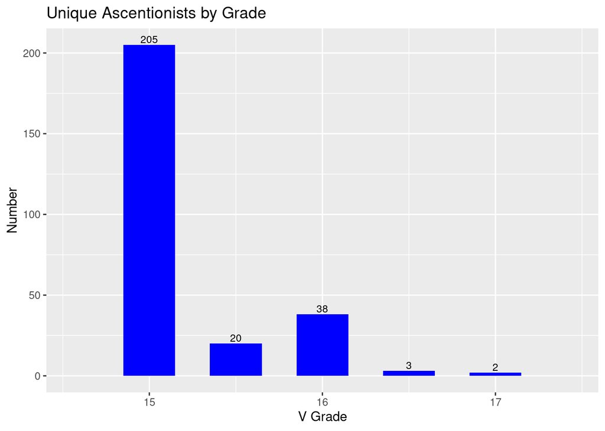

At the moment, there are more than 200 climbers in the world that have sent V15. After which there is a steep drop off, with 20 unique climbers having sent V15/16, 38 having sent V16, and 3 and 2 having sent V16/17 and V17, respectively.

With hard boulders, downgrading is common, as new climbers come along and find better/easier beta. Nalle wrote a fantastic [blog post](https://nalle-hukkataival.blogspot.com/2010/03/bouldering-grades-everything-is-average.html) back in 2010 giving his thoughts on hard boulder grades.

# Which Countries Have the Hardest Boulder Problems?

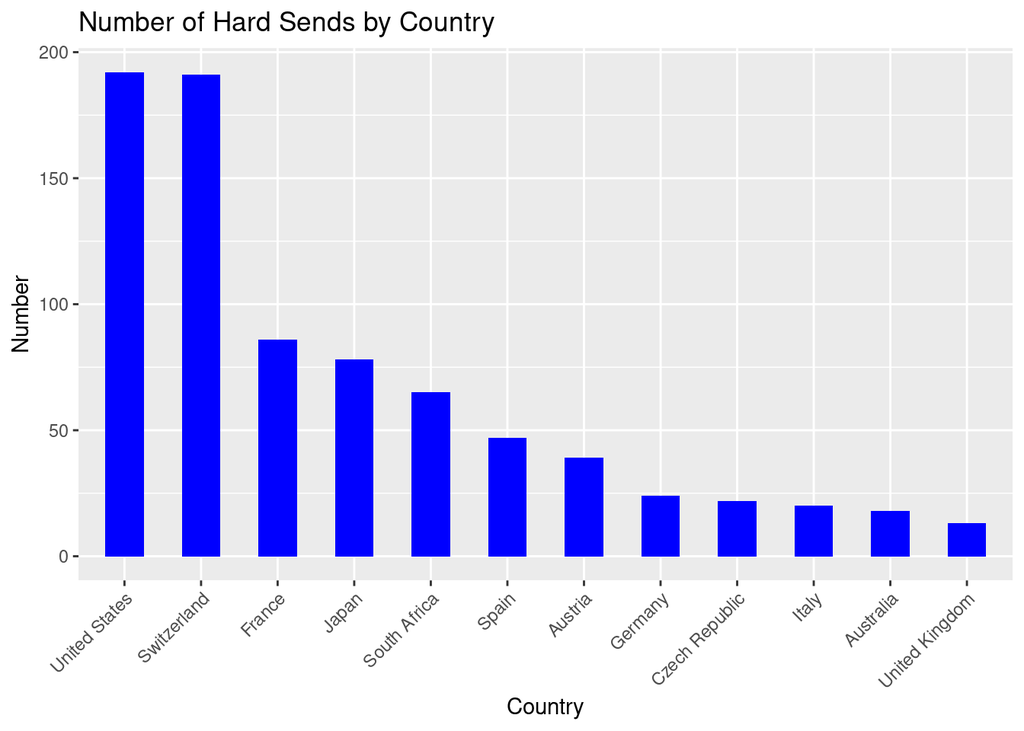

# What About Age?

What is the age of strong male climbers today?

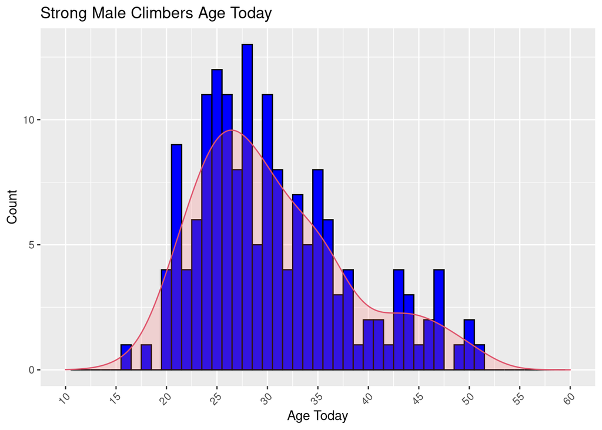

The mean, median and mode age of strong male climbers today is 31, 29, and 28, respectively.

The youngest V15 climber today is 16 years old. The oldest V15 climber today is 51 years old.

## What About Stats on How Old They Are When They Sent?

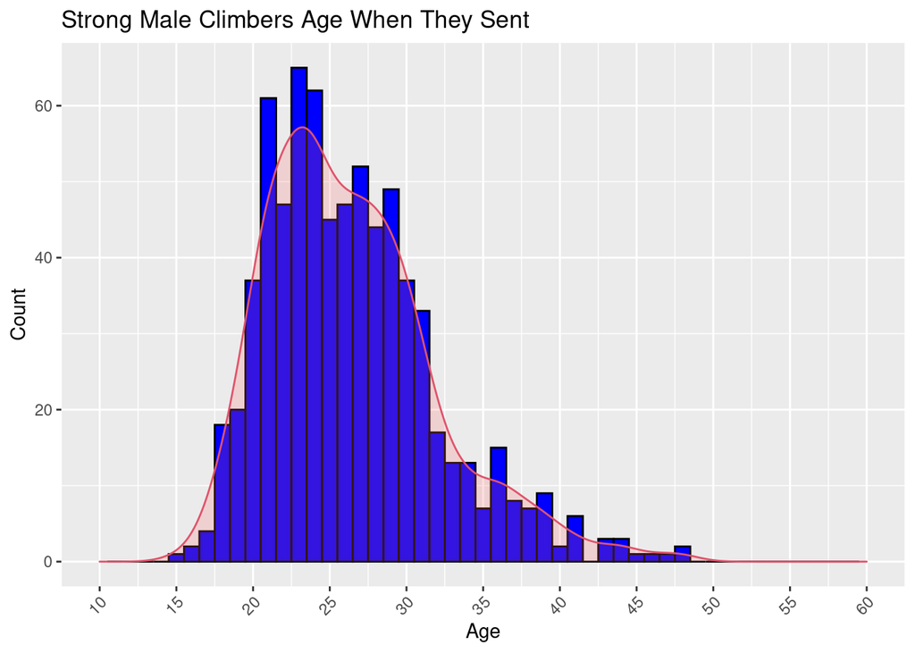

The mean, median and mode age of strong male climbers when they sent is 26, 26, and 23, respectively.

The youngest age to have climbed V15 or higher is 15 years old. The oldest age to have climbed V15 or higher is 48 years old.

# Climber’s Height

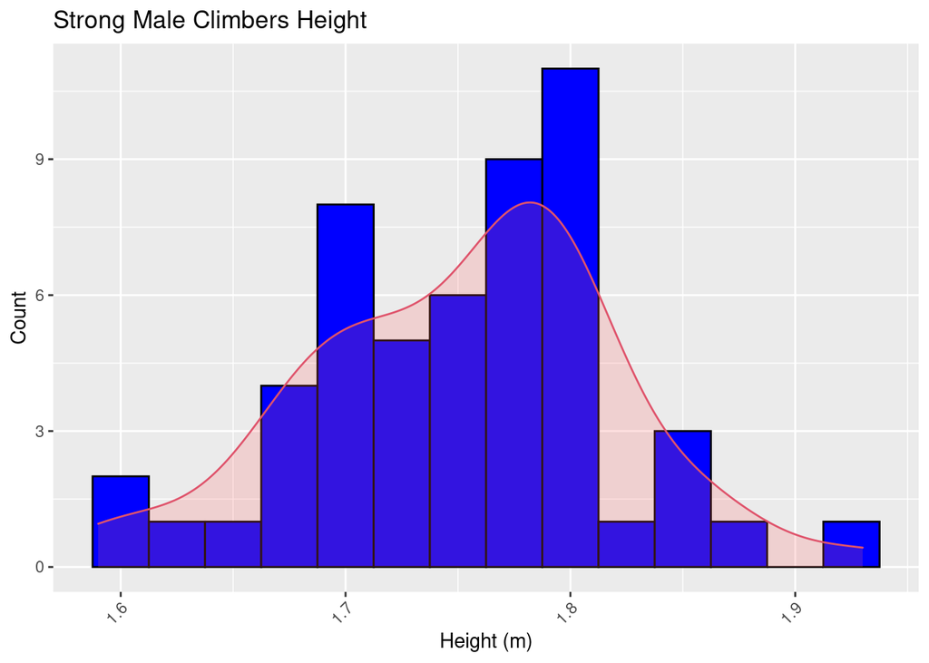

The mean, median and mode height of strong male climbers is 1.75, 1.76, and 1.8, respectively.

The shortest height to have climbed V15 or higher is 1.59 meters. The tallest height to have climbed V15 or higher is 1.93 meters.

*In order to create this list, I first copied Mr. Beale’s list. Then, realizing that [scraping](https://github.com/vishaalagartha/8a_scraper) [8a.nu](https://www.8a.nu/) is against their terms of service, I simply clicked on their ‘Ascents’ tab, clicked ‘Bouldering’ for the discipline, filtered grades from 8c and higher, and copied the table:*

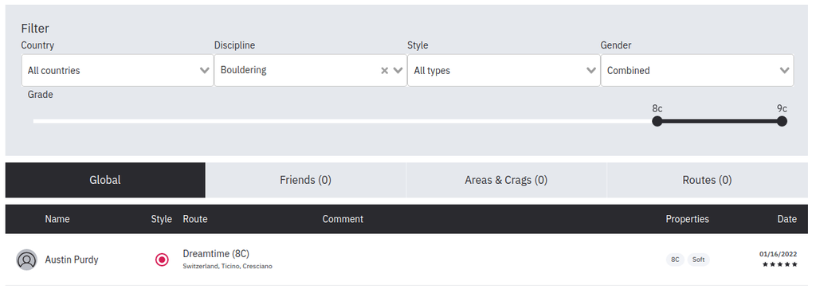

8a.nu filter

*However, not all athlete’s record their bouldering ascents in 8a.nu (Alex Megos being one example). Another great resource was https://climbing-history.org/, where oftentimes searching for a popular boulder problem would reveal additional sends not listed in 8a.nu.*

*Finally, I then tried to standardize all entries (James Webb vs. Jimmy Webb), remove errors, and add in send dates. Ultimately this is still a work in progress, and if you see any errors, please reach out.*

*Special shout-out to Andrew Leyland for extensive help in filling out the spreadsheet. And for those curious, I used [this tutorial](https://resources.github.com/whitepapers/github-and-rstudio/) to create this site.*